# Introduction to TRACLUS

**Note:** This package was developed as part of a university course project (*Data Analytics – Unsupervised Learning*, TU Dresden). The vignette is intentionally detailed and explains each step from the ground up.

This vignette walks through each phase using a small toy dataset. For a real-world application to the NHC Atlantic hurricane database, see the HURDAT2 case study at the end of this document.

## Overview

TRACLUS (TRAjectory CLUStering) is a partition-and-group algorithm for clustering spatial trajectories. Rather than treating each trajectory as a single object, TRACLUS first partitions trajectories into line segments and then clusters those segments. This allows the algorithm to discover common sub-trajectories even when the full trajectories differ substantially.

The algorithm was introduced by Lee, Han, and Whang (2007) and consists of three phases:

1. **Partition** each trajectory into characteristic line segments using the Minimum Description Length (MDL) principle
2. **Cluster** the resulting segments using a density-based approach adapted from DBSCAN
3. **Summarise** each cluster into a single representative trajectory via a sweep-line procedure

## The toy dataset

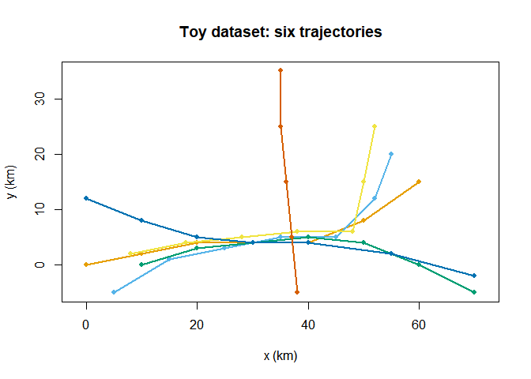

```r
trajs <- make_toy_trajectories()
plot_trajectories(trajs, "Toy dataset: six trajectories")
```

```r
# trajs is a named list of matrices, one per trajectory.
# Each matrix has two columns (x, y) and one row per recorded position.
str(trajs[1])  # preview the first trajectory
```

```
#> List of 1
#>  $ TR1: num [1:7, 1:2] 0 10 20 30 40 50 60 0 2 4 ...
#>   ..- attr(*, "dimnames")=List of 2
#>   .. ..$ : NULL
#>   .. ..$ : chr [1:2] "x" "y"
```

## The distance function

TRACLUS measures the similarity between two line segments using a weighted sum of three components. Given a longer segment $L_i$ and a shorter segment $L_j$, the total distance is:

$$\text{dist}(L_i, L_j) = w_\perp \cdot
d_\perp + w_\parallel \cdot d_\parallel + w_\theta \cdot
d_\theta$$

The figure below (from the original paper) illustrates how the three components relate to the geometry of two line segments. $p_s$ and $p_e$ are the projections of $L_j$’s endpoints onto the line through $L_i$.

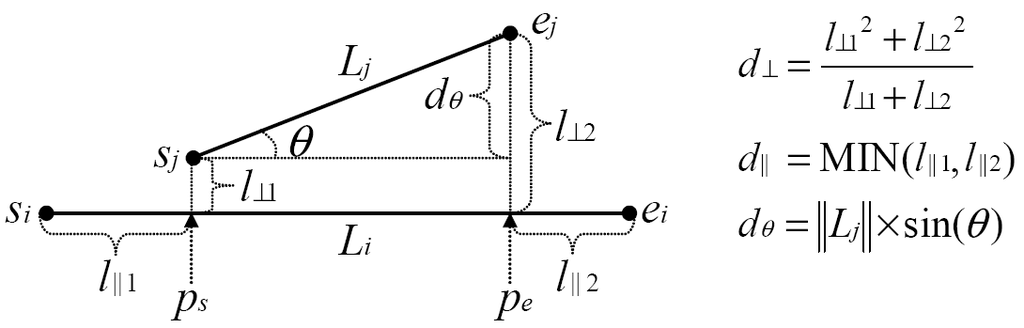

Source: Lee, J.-G., Han, J. and Whang, K.-Y. (2007), Figure 5. Reproduced for educational purposes under fair use.

The three components are:

- $d_\perp$: **perpendicular distance**. Measures how far $L_j$ sits off the line through $L_i$. The two perpendicular distances $l_{\perp 1}$ and $l_{\perp 2}$ are combined via a Lehmer mean (order 2), which pulls the result toward the larger of the two values. This means that if one endpoint of $L_j$ is far off the line and the other is close, the result is closer to the larger deviation than a plain average would give.
- $d_\parallel$: **parallel distance**. Measures how far $L_j$ extends beyond the endpoints of $L_i$ along $L_i$’s own axis. The minimum of the two projection distances is used so that a slight longitudinal overhang on one side does not dominate.
- $d_\theta$: **angle distance**. Equal to the length of $L_j$ scaled by $\sin(\theta)$, where $\theta$ is the smaller angle between the two segments. When the angle reaches or exceeds 90 degrees, the full length of $L_j$ is returned as the worst-case penalty.

These three components serve different roles in the algorithm. In the **MDL partitioning** phase, only $d_\perp$ and $d_\theta$ are used to measure how much each raw sub-segment deviates from a candidate partition. The parallel distance is not needed here because a trajectory always encloses its own partitions (Lee et al. 2007, Section 3.2). In the **clustering** phase, all three components are combined with their weights to determine which segments are neighbours. The **representative trajectory** phase does not use the distance function directly; it operates on the geometric positions of the clustered segments via a sweep-line procedure.

The entire pairwise distance computation in the clustering phase is implemented in C++ via Rcpp. This is the most expensive step of the algorithm (quadratic in the number of segments), and the C++ implementation avoids the overhead of n-squared R-level function calls.

```r
# Individual distance components between two example segments
si <- c(0, 0);  ei <- c(10, 0)  # Li: horizontal
sj <- c(2, 3);  ej <- c(8, 5)   # Lj: offset and slightly tilted

dist_perpendicular(si, ei, sj, ej)
```

```
#> [1] 4.25
```

```r
dist_parallel(si, ei, sj, ej)
```

```
#> [1] 2
```

```r
dist_angle(si, ei, sj, ej)
```

```
#> [1] 2
```

```r
# Combined distance (default weights: all 1)
dist_segments(si, ei, sj, ej, w_perp = 1, w_par = 1, w_angle = 1)
```

```
#> [1] 8.25
```

The weights `w_perp`, `w_par`, and `w_angle` are all 1 by default. Lee et al. (2007) report that equal weights work well across a range of applications. Adjusting them shifts the clustering focus:

- Increase `w_perp` to emphasise spatial proximity. Segments far apart perpendicular to their direction will be separated more aggressively.
- Increase `w_angle` to emphasise directional similarity. Segments pointing in different directions will be harder to cluster even if spatially close.
- Set a weight to 0 to ignore that component entirely.

```r
# TR1-like segment: nearly horizontal
tr1_start <- c(0, 0);  tr1_end <- c(40,  4)
# TR6 segment: near-vertical outlier
tr6_start <- c(35, 35); tr6_end <- c(38, -5)

# Default: equal weights
dist_segments(tr1_start, tr1_end, tr6_start, tr6_end,
              w_perp = 1, w_par = 1, w_angle = 1)
```

```
#> [1] 68.41436
```

```r
# Direction-focused: angle component doubled
dist_segments(tr1_start, tr1_end, tr6_start, tr6_end,
              w_perp = 1, w_par = 1, w_angle = 2)
```

```
#> [1] 108.5267
```

```r
# Position only: direction ignored
dist_segments(tr1_start, tr1_end, tr6_start, tr6_end,
              w_perp = 1, w_par = 1, w_angle = 0)
```

```
#> [1] 28.30202
```

The large angle distance between TR1 and TR6 foreshadows why TR6 will not be assigned to any cluster in the grouping phase.

## Phase 1: MDL partitioning

The partitioning phase converts each trajectory into a compact set of line segments. The MDL principle balances two competing costs:

- $L(H)$: the cost of encoding the partition itself (fewer, longer segments are cheaper)
- $L(D|H)$: the cost of encoding the deviation of the raw points from the partition (smaller deviations are cheaper). This cost is measured using $d_\perp$ and $d_\theta$ only, as explained in the distance function section above.

Imagine a trajectory that first runs straight and then makes a sharp turn. While the greedy scan is on the straight section, a single segment covers all points with very little deviation, so $L(D|H)$ is small and keeping one long segment is cheaper than storing many short ones. As soon as the turn begins, the deviation from the single-segment hypothesis grows rapidly and $L(D|H)$ spikes. At that point, splitting becomes cheaper: the previous point is recorded as a characteristic point and the scan restarts from there.

```r
segs <- partition_trajectories(trajs)

# segs is a data frame with one row per segment.
# Each row contains the trajectory ID, segment index, and start/end coordinates.
head(segs)
```

```
#>   traj_id seg_id sx sy ex ey
#> 1     TR1      1  0  0 60 15
#> 2     TR2      1  5 -5 15  1
#> 3     TR2      2 15  1 45  5
#> 4     TR2      3 45  5 52 12
#> 5     TR2      4 52 12 55 20
#> 6     TR3      1 10  0 50  4
```

```r
cat("Trajectories:", length(trajs), "\n")
```

```
#> Trajectories: 6
```

```r
cat("Segments:    ", nrow(segs),    "\n")
```

```
#> Segments:     11
```

```r
# Each trajectory is reduced to a small number of characteristic segments
cat("\nSegments per trajectory:\n")
```

```
#>
#> Segments per trajectory:
```

```r
print(table(segs$traj_id))
```

```
#>
#> TR1 TR2 TR3 TR4 TR5 TR6
#>   1   4   2   2   1   1
```

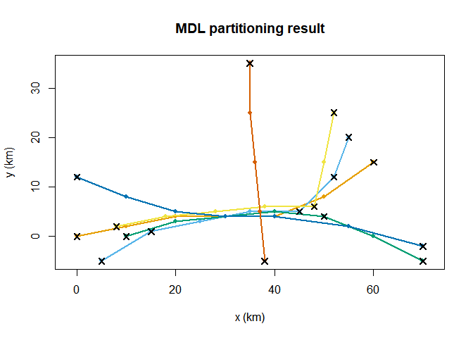

```r
plot_trajectories(trajs, "MDL partitioning result")

# Mark characteristic points (segment boundaries)
starts <- segs[, c("sx", "sy")]
ends   <- segs[, c("ex", "ey")]
colnames(ends) <- c("sx", "sy")
char_points <- unique(rbind(starts, ends))
points(char_points[, 1], char_points[, 2], pch = 4, cex = 1.2, lwd = 2)
```

## Phase 2: Density-based clustering

The clustering phase adapts DBSCAN to line segments, using the full weighted distance function ($d_\perp$, $d_\parallel$, $d_\theta$) to determine which segments are neighbours. Two parameters control the result:

- `eps`: distance threshold in the same unit as the coordinates (km for projected data). Two segments are neighbours if their TRACLUS distance is at or below `eps`.
- `min_lns`: minimum neighbourhood size for a segment to qualify as a core segment. The same threshold is also applied as a minimum trajectory cardinality: clusters whose segments originate from fewer than `min_lns` distinct trajectories are discarded.

```r
clustered_segs <- cluster_segments(segs,
                                   eps     = 20,
                                   min_lns = 3,
                                   w_perp  = 1,
                                   w_par   = 1,
                                   w_angle = 1)

cat("Cluster assignments:\n")
```

```
#> Cluster assignments:
```

```r
print(table(clustered_segs$cluster_id, useNA = "ifany"))
```

```
#>
#>    1 <NA>
#>   10    1
```

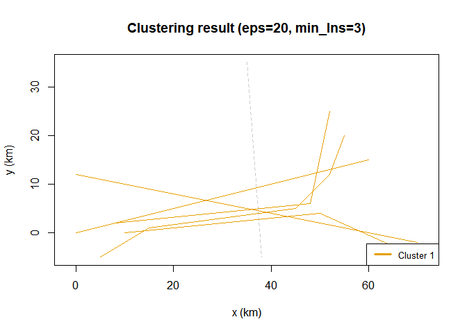

```r
plot_traclus_result(clustered_segs, title = "Clustering result (eps=20, min_lns=3)")
```

## Phase 3: Representative trajectory

For each cluster, a sweep line moves along the average direction of the cluster. Think of a ruler placed perpendicular to the cluster’s main axis, sliding from one end to the other. At each position where the ruler crosses at least `min_lns` segments, the average of the crossing points is recorded as a waypoint. The sequence of these waypoints forms the representative trajectory.

Note that `min_lns` appears both in the clustering phase and here. In clustering, it controls the minimum neighbourhood size for core segments. In the representative trajectory phase, it controls the minimum number of simultaneously active segments required to emit a waypoint. Lee et al. (2007) use the same value for both because the underlying idea is the same: how many segments need to come together before we consider a pattern genuine?

The `gamma` parameter is the minimum spacing between consecutive waypoints, measured along the cluster’s average direction axis. A smaller `gamma` allows waypoints to be placed closer together, producing a more detailed representative trajectory. A larger `gamma` enforces wider spacing and a smoother result.

```r
reps <- compute_all_representatives(clustered_segs,
                                    min_lns = 3,
                                    gamma   = 1)
cat("Clusters with a representative:", length(reps), "\n")
```

```
#> Clusters with a representative: 1
```

```r
# You can also compute the representative for a single cluster directly:
single_cluster <- clustered_segs[!is.na(clustered_segs$cluster_id) &
                                   clustered_segs$cluster_id == 1, ]
rt <- compute_representative(single_cluster, min_lns = 3, gamma = 1)
head(rt)
```

```
#>              x        y
#> [1,]  3.836552 2.509526
#> [2,]  7.848523 2.977718
#> [3,]  9.595228 2.612617
#> [4,] 14.687947 3.014161
#> [5,] 44.918269 5.527533
#> [6,] 47.958003 6.271071
```

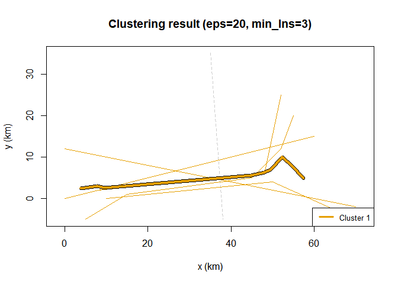

```r
reps_toy <- compute_all_representatives(clustered_segs,
                                        min_lns = 3,
                                        gamma   = 1)
plot_traclus_result(clustered_segs, reps_toy,
                    title = "Clustering result (eps=20, min_lns=3)")
```

The bold coloured line in the plot above summarises the shared movement pattern of the five clustered trajectories through the middle section.

## Full pipeline

The `traclus()` function runs all three phases in sequence:

```r
traclus_result <- traclus(make_toy_trajectories(),
                          eps     = 20,
                          min_lns = 3,
                          w_perp  = 1,
                          w_par   = 1,
                          w_angle = 1,
                          gamma   = 1)
```

```
#> Partitioning 6 trajectories...
#>   -> 11 line segments
#> Clustering segments...
#>   -> 1 clusters, 1 noise segments
#> Computing representative trajectories...
#>   -> 1 representative trajectories
```

```r
str(traclus_result$params)
```

```
#> List of 6
#>  $ eps    : num 20
#>  $ min_lns: num 3
#>  $ w_perp : num 1
#>  $ w_par  : num 1
#>  $ w_angle: num 1
#>  $ gamma  : num 1
```

```r
print(table(traclus_result$segments$cluster_id, useNA = "ifany"))
```

```
#>
#>    1 <NA>
#>   10    1
```

```r
cat("\nRepresentatives found:", length(traclus_result$representatives), "\n")
```

```
#>
#> Representatives found: 1
```

## Parameter selection

### Choosing `eps`

Choosing `eps` is the most important tuning step. The `estimate_eps` function implements the entropy heuristic from Section 4.4 of Lee et al. (2007). It evaluates a grid of candidate epsilon values and computes the entropy of the neighbourhood-size distribution at each one.

The idea is that at a good `eps` value, the neighbourhood sizes are skewed: a few dense regions contain many segments while most segments sit in sparse areas. This skewness corresponds to low entropy. At a bad `eps` (too small or too large), neighbourhood sizes tend to be uniform and entropy is high.

```r
eps_estimate <- estimate_eps(segs, sample_size = 200L)
cat("Suggested eps:", round(eps_estimate$eps_opt, 2), "\n")
```

```
#> Suggested eps: 26.27
```

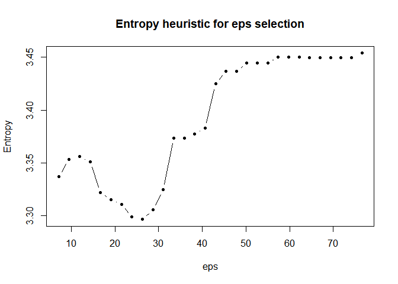

```r
plot(eps_estimate$entropy_df$eps, eps_estimate$entropy_df$entropy,
     type = "b", pch = 19, cex = 0.7,
     xlab = "eps", ylab = "Entropy",
     main = "Entropy heuristic for eps selection")
```

The entropy curve should be treated as a rough guide, not an oracle. The global minimum is one candidate, but positions where the entropy drops sharply can be equally informative since they indicate that structure is emerging at that scale. In practice, the most reliable approach is to use the curve to narrow down the search range and then try a few values by visual inspection. Simply experimenting with different `eps` values and comparing the resulting clusters is a perfectly legitimate strategy.

Note: on small datasets like this toy example the entropy curve is noisy because too few segments are available to produce a meaningful neighbourhood-size distribution. The heuristic works best with hundreds to thousands of segments.

### Choosing `min_lns`

Lee et al. (2007) recommend computing the average neighbourhood size at the selected `eps` and setting `min_lns` to that average plus 1 to 3. The idea is that `min_lns` should be slightly above the average density so that only genuinely dense regions qualify as clusters.

In practice: run `estimate_eps` on your dataset, pick an `eps` from the promising range, then try a few values of `min_lns` and compare the results by visual inspection. For the toy dataset with only five trajectories sharing a common pattern, `min_lns = 3` is a natural starting point.

## Visualisation modes

`plot_traclus_result` offers two display modes. In `"clusters"` mode (the default), each cluster’s segments share the colour of their representative trajectory. In `"representatives"` mode, all clustered segments are drawn in a neutral grey and only the representative trajectories carry colour.

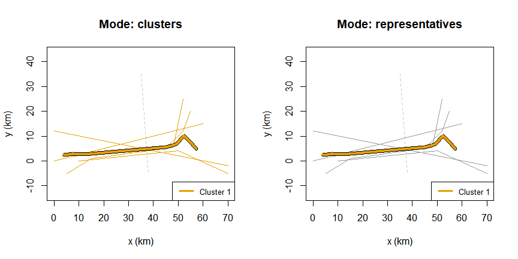

```r
par(mfrow = c(1, 2))
plot_traclus_result(clustered_segs, reps_toy,
                    mode = "clusters",
                    title = "Mode: clusters")
plot_traclus_result(clustered_segs, reps_toy,
                    mode = "representatives",
                    title = "Mode: representatives")
```

## Application: Atlantic hurricanes (HURDAT2)

The HURDAT2 (Hurricane Database 2) best-track file published by NOAA’s National Hurricane Center contains the position, intensity, and size of all known Atlantic tropical and subtropical cyclones at 6-hourly intervals, going back to 1851.

Following Lee et al. (2007), we use the Atlantic hurricanes from the years 1950 through 2004.

### Loading and projecting the data

`read_hurdat2()` parses the raw fixed-width text file and converts geographic coordinates (latitude/longitude in degrees) to a Cartesian plane in kilometres. The projection uses an equirectangular approximation centred on the dataset mean. This is not a geodetically precise projection, but the distance error relative to the Haversine formula stays below 2% over the Atlantic basin (roughly 10 degrees N to 60 degrees N, 20 degrees W to 100 degrees W), which is acceptable for the relative distance comparisons that TRACLUS performs.

```r
path   <- system.file("extdata", "hurdat2-1851-2024-040425.txt",
                       package = "TRACLUS")
hurdat <- read_hurdat2(path)
```

```
#> Loaded 1959 trajectories
```

```r
# Subset to 1950-2004, matching the evaluation period in Lee et al. (2007)
storm_years <- as.integer(substr(names(hurdat), 5, 8))
hurdat_sub  <- hurdat[storm_years >= 1950 & storm_years <= 2004]

cat("Storms loaded (total):", length(hurdat), "\n")
```

```
#> Storms loaded (total): 1959
```

```r
cat("Storms in 1950-2004: ", length(hurdat_sub), "\n")
```

```
#> Storms in 1950-2004:  825
```

### Partitioning

```r
hurdat_segs <- partition_trajectories(hurdat_sub)
cat("Line segments:", nrow(hurdat_segs), "\n")
```

```
#> Line segments: 15264
```

```r
cat("\nSegments per storm (summary):\n")
```

```
#>
#> Segments per storm (summary):
```

```r
print(summary(as.integer(table(hurdat_segs$traj_id))))
```

```
#>    Min. 1st Qu.  Median    Mean 3rd Qu.    Max.
#>     1.0     8.0    15.0    18.5    26.0    75.0
```

### Parameter estimation

With thousands of segments the entropy heuristic produces a smoother curve. We evaluate candidates between 1 and 250 km, which covers the range where cluster structure typically begins to emerge for hurricane track data.

```r
hurdat_est <- estimate_eps(hurdat_segs,
                           eps_grid    = seq(1, 250, length.out = 30),
                           sample_size = 500L)
cat("Entropy-minimum eps:", round(hurdat_est$eps_opt, 1), "\n")
```

```
#> Entropy-minimum eps: 250
```

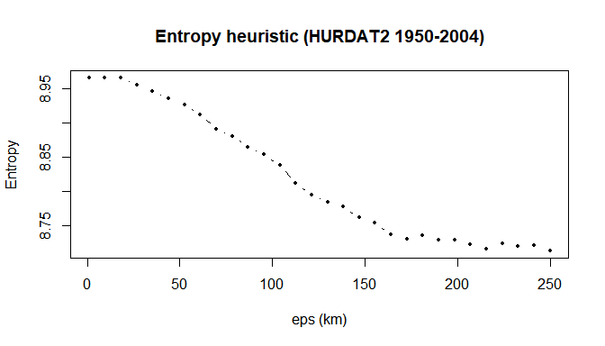

```r
plot(hurdat_est$entropy_df$eps, hurdat_est$entropy_df$entropy,
     type = "b", pch = 19, cex = 0.6,
     xlab = "eps (km)", ylab = "Entropy",
     main = "Entropy heuristic (HURDAT2 1950-2004)")
```

### Clustering and representative trajectories

```r
hurdat_clustered <- cluster_segments(hurdat_segs,
                                     eps     = 85,
                                     min_lns = 5,
                                     w_perp  = 1,
                                     w_par   = 1,
                                     w_angle = 1)

n_cl <- length(unique(hurdat_clustered$cluster_id[
  !is.na(hurdat_clustered$cluster_id)]))
n_ns <- sum(is.na(hurdat_clustered$cluster_id))
cat("Clusters:", n_cl, "\n")
```

```
#> Clusters: 3
```

```r
cat("Noise segments:", n_ns, "of", nrow(hurdat_clustered), "\n")
```

```
#> Noise segments: 2218 of 15264
```

```r
hurdat_reps <- compute_all_representatives(hurdat_clustered,
                                           min_lns = 5,
                                           gamma   = 200)
cat("Representative trajectories:", length(hurdat_reps), "\n")
```

```
#> Representative trajectories: 3
```

### Visualisation

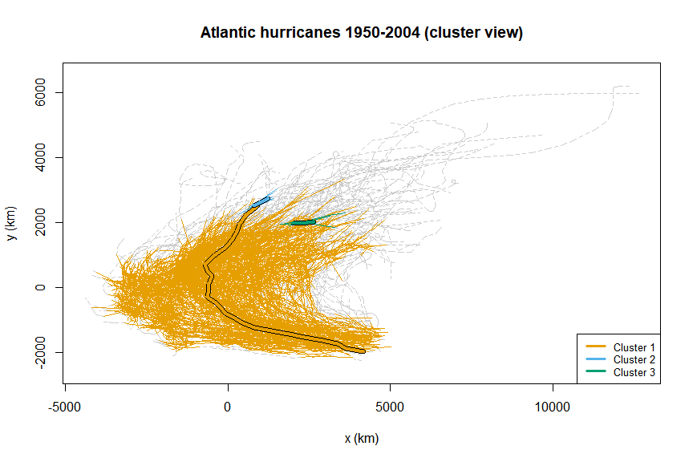

```r
plot_traclus_result(hurdat_clustered, hurdat_reps,
                    mode    = "clusters",
                    title   = "Atlantic hurricanes 1950-2004 (cluster view)",
                    seg_lwd = 0.8, noise_lwd = 0.3)
```

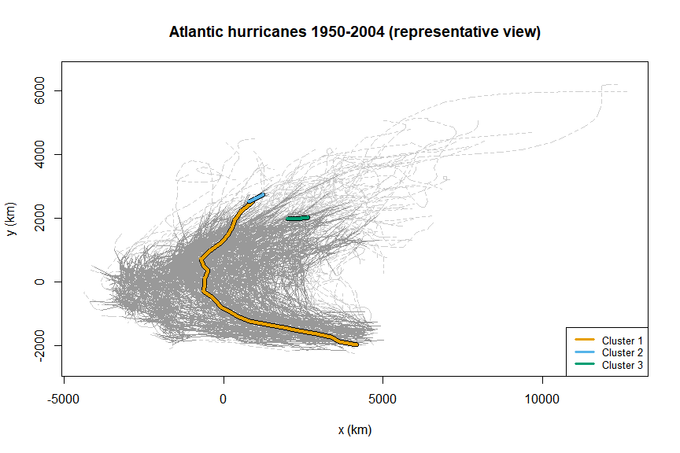

```r
plot_traclus_result(hurdat_clustered, hurdat_reps,
                    mode    = "representatives",
                    title   = "Atlantic hurricanes 1950-2004 (representative view)",
                    seg_lwd = 0.5, noise_lwd = 0.3)
```

```r
library(leaflet)
library(sf)
```

```r
# Retrieve the projection origin (in radians) used by .project_to_cartesian
lat_ref <- attr(hurdat, "lat_ref")
lon_ref <- attr(hurdat, "lon_ref")

# Back-project km coordinates to geographic lat/lon (inverse of the equirectangular projection)
km_to_lat <- function(y) (lat_ref + y / 6371.0) * 180 / pi
km_to_lon <- function(x) (lon_ref + x / (6371.0 * cos(lat_ref))) * 180 / pi

# Helper: convert segment rows to a single MULTILINESTRING sf object
segs_to_sf <- function(segs) {
  lines <- lapply(seq_len(nrow(segs)), function(i) {
    st_linestring(matrix(c(
      km_to_lon(c(segs$sx[i], segs$ex[i])),
      km_to_lat(c(segs$sy[i], segs$ey[i]))
    ), ncol = 2))
  })
  st_sfc(lines, crs = 4326)
}

pal <- c("#E69F00", "#56B4E9", "#009E73", "#F0E442",
         "#0072B2", "#D55E00", "#CC79A7", "#000000")
cluster_ids <- sort(unique(hurdat_clustered$cluster_id[
  !is.na(hurdat_clustered$cluster_id)]))

m <- leaflet() |> addProviderTiles(providers$CartoDB.Positron)

# Noise segments in grey, dashed
noise_h <- hurdat_clustered[is.na(hurdat_clustered$cluster_id), ]
if (nrow(noise_h) > 0L) {
  m <- m |> addPolylines(data = segs_to_sf(noise_h),
                         color = "#999999", weight = 0.5, opacity = 0.4,
                         dashArray = "4 4")
}

# One layer per cluster (single addPolylines call each)
for (k in seq_along(cluster_ids)) {
  cid   <- cluster_ids[k]
  csub  <- hurdat_clustered[!is.na(hurdat_clustered$cluster_id) &
                              hurdat_clustered$cluster_id == cid, ]
  col_k <- pal[(k - 1L) %% length(pal) + 1L]
  m <- m |> addPolylines(data = segs_to_sf(csub),
                         color = col_k, weight = 1, opacity = 0.6)
}

# Representative trajectories as single polylines with black outline
for (k in seq_along(hurdat_reps)) {
  rt    <- hurdat_reps[[k]]
  col_k <- pal[(k - 1L) %% length(pal) + 1L]
  coords <- matrix(c(km_to_lon(rt[, "x"]), km_to_lat(rt[, "y"])), ncol = 2)
  line_sf <- st_sfc(st_linestring(coords), crs = 4326)
  # Black outline first, then coloured line on top
  m <- m |> addPolylines(data = line_sf,
                         color = "black", weight = 7, opacity = 1)
  m <- m |> addPolylines(data = line_sf,
                         color = col_k, weight = 5, opacity = 1,
                         popup = paste("Cluster", names(hurdat_reps)[k]))
}

# Legend matching cluster colours
m <- m |> addLegend(
  position = "bottomright",
  colors   = c("#999999", pal[seq_along(hurdat_reps)]),
  labels   = c("Noise", paste("Cluster", names(hurdat_reps))),
  title    = "Clusters",
  opacity  = 1
)

m
```

[interactive chart not shown]

### Interpretation

Each representative trajectory (bold coloured line) summarises a common hurricane movement pattern. Typical patterns in the Atlantic basin include east-to-west tracks through the Caribbean, recurving tracks that turn northward along the U.S. East Coast, and straight westward tracks at low latitudes. The noise segments (grey, dashed) correspond to storm track portions that do not share direction or position with enough other storms to form a cluster.

The exact number and shape of clusters depends on `eps` and `min_lns`. A smaller `eps` produces more, tighter clusters; a larger `eps` merges nearby patterns into broader clusters. The entropy heuristic provides a starting range, but trying a few values and comparing the results visually is the most reliable approach.

## References

Lee, J.-G., Han, J., and Whang, K.-Y. (2007). Trajectory clustering: a partition-and-group framework. *Proceedings of the 2007 ACM SIGMOD International Conference on Management of Data*, 593-604. https://doi.org/10.1145/1247480.1247546

National Hurricane Center (2025). Atlantic hurricane database (HURDAT2). National Oceanic and Atmospheric Administration. https://www.nhc.noaa.gov/data/